Skip to contents

# How to create volker reports?

Source: [`vignettes/reports.Rmd`](https://github.com/strohne/volker/blob/main/vignettes/reports.Rmd)

Reports combine graphs, tables, indexes and additional output.´ The volker package comes with a Markdown template that generates interactive HTML documents in which you can switch between the different parts of the report.

How to use the template: - Create a new R Markdown document from the menu - Select “From template”

Alternatively, manually add `volker::html_report` to the output options of your Markdown document:

```
---
title: "How to create reports?"
output:
  volker::html_report
---
```

Then, you can generate combined outputs using the report-functions. One advantage of the report-functions is that plots are automatically scaled to fit the page.

## A single categorical variable

```r
report_counts(data, sd_gender)
```

##### Gender

###### Plot

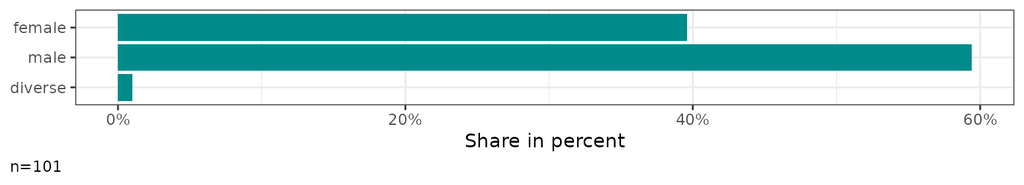

###### Table

| Gender | n | p |
| --- | --- | --- |
| female | 40 | 40% |
| male | 60 | 59% |
| diverse | 1 | 1% |
| total | 101 | 100% |

*n=101.*

## A cross table

```r
data %>%
  filter(sd_gender != "diverse") %>%
  filter(adopter != "I only use new offers when I have no other choice") %>%
  report_counts(adopter, sd_gender, prop="rows", title="Innovator")
```

##### Innovator

###### Plot

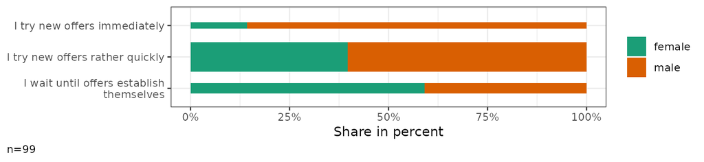

###### Table

| Innovator type | total | female | male |
| --- | --- | --- | --- |
| I try new offers immediately | 100% (14) | 14% (2) | 86% (12) |
| I try new offers rather quickly | 100% (63) | 40% (25) | 60% (38) |
| I wait until offers establish themselves | 100% (22) | 59% (13) | 41% (9) |
| total | 100% (99) | 40% (40) | 60% (59) |

*n=99.*

## Group comparisons

```r
data %>%
  filter(sd_gender != "diverse") %>%
  filter(adopter != "I only use new offers when I have no other choice") %>%
  report_metrics(starts_with("cg_adoption_"), sd_gender)
```

##### Expectations

###### Plot

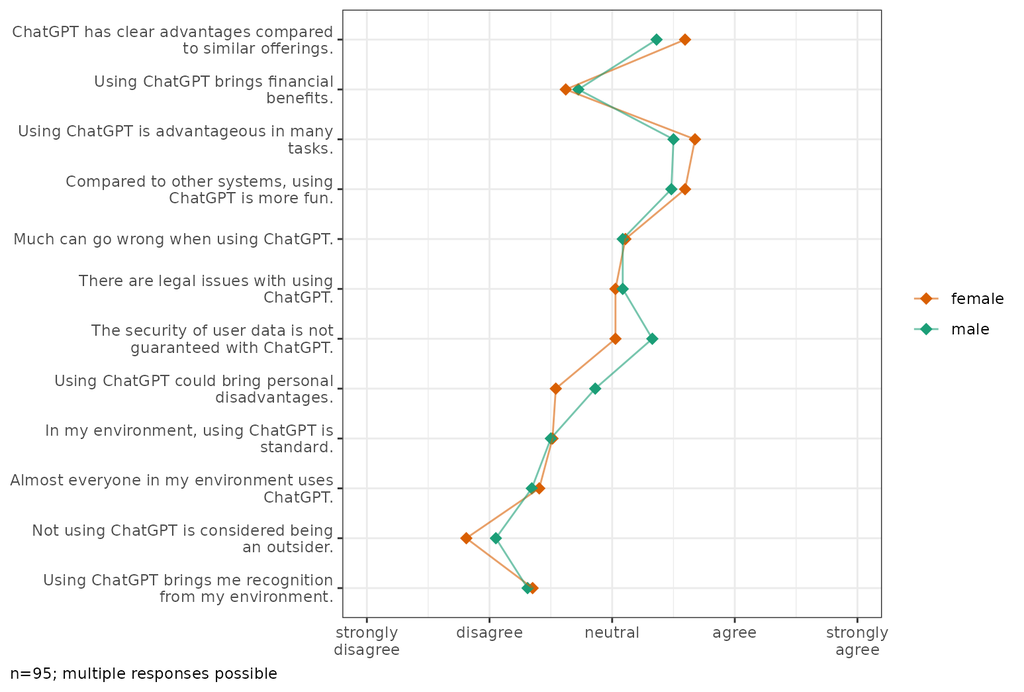

*4 missing case(s) omitted.*

###### Table

| Expectations | total | female | male |
| --- | --- | --- | --- |
| ChatGPT has clear advantages compared to similar offerings. | 3.5 (1.0) | 3.6 (1.0) | 3.4 (1.0) |
| Using ChatGPT brings financial benefits. | 2.7 (1.2) | 2.6 (1.2) | 2.7 (1.2) |
| Using ChatGPT is advantageous in many tasks. | 3.6 (1.1) | 3.7 (1.0) | 3.5 (1.1) |
| Compared to other systems, using ChatGPT is more fun. | 3.5 (1.0) | 3.6 (1.0) | 3.5 (1.0) |
| Much can go wrong when using ChatGPT. | 3.1 (1.1) | 3.1 (1.0) | 3.1 (1.2) |
| There are legal issues with using ChatGPT. | 3.1 (1.2) | 3.0 (1.0) | 3.1 (1.3) |
| The security of user data is not guaranteed with ChatGPT. | 3.2 (1.0) | 3.0 (1.0) | 3.3 (1.1) |
| Using ChatGPT could bring personal disadvantages. | 2.7 (1.1) | 2.5 (0.9) | 2.9 (1.2) |
| In my environment, using ChatGPT is standard. | 2.5 (1.1) | 2.5 (0.9) | 2.5 (1.3) |
| Almost everyone in my environment uses ChatGPT. | 2.4 (1.2) | 2.4 (1.0) | 2.3 (1.3) |
| Not using ChatGPT is considered being an outsider. | 2.0 (1.2) | 1.8 (1.0) | 2.1 (1.3) |
| Using ChatGPT brings me recognition from my environment. | 2.3 (1.3) | 2.4 (1.2) | 2.3 (1.3) |
| n | 95 | 37 | 58 |

*n=95. 4 missing case(s) omitted.*

## Mix in your own content

If you want to add content before the outputs, set the title parameter to `FALSE` and add your own title.

A good place for methodological details is a tabsheet next to the “Plot” and the “Table” buttons. You can add a tab by setting the close-parameter to `FALSE` and adding a new header on the fifth level (5 x # followed by the tab name). Close your new tabsheet with `#### {-}` (4 x #). See the example Markdown behind this vignette.

##### Adoption types

```r
data %>%
  filter(sd_gender != "diverse") %>%
  filter(adopter != "I only use new offers when I have no other choice") %>%
  report_counts(adopter, sd_gender, prop="rows", title= FALSE, close= FALSE, effect=T)
```

###### Plot

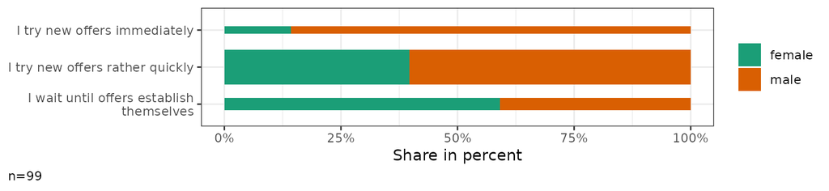

###### Table

| Innovator type | total | female | male |
| --- | --- | --- | --- |
| I try new offers immediately | 100% (14) | 14% (2) | 86% (12) |
| I try new offers rather quickly | 100% (63) | 40% (25) | 60% (38) |
| I wait until offers establish themselves | 100% (22) | 59% (13) | 41% (9) |
| total | 100% (99) | 40% (40) | 60% (59) |

*n=99.*

###### Effects

| adopter | sd_gender | n | p_x | p_y | p_xy | ratio | pmi | npmi | fisher_p | fisher_stars |
| --- | --- | --- | --- | --- | --- | --- | --- | --- | --- | --- |
| I try new offers immediately | female | 2 | 0.14 | 0.4 | 0.02 | 0.35 | -1.50 | -0.27 | 0.077 | . |
| I try new offers immediately | male | 12 | 0.14 | 0.6 | 0.12 | 1.44 | 0.52 | 0.17 | 0.077 | . |
| I try new offers rather quickly | female | 25 | 0.64 | 0.4 | 0.25 | 0.98 | -0.03 | -0.01 | 1.000 |  |
| I try new offers rather quickly | male | 38 | 0.64 | 0.6 | 0.38 | 1.01 | 0.02 | 0.01 | 1.000 |  |
| I wait until offers establish themselves | female | 13 | 0.22 | 0.4 | 0.13 | 1.46 | 0.55 | 0.19 | 0.077 | . |
| I wait until offers establish themselves | male | 9 | 0.22 | 0.6 | 0.09 | 0.69 | -0.54 | -0.16 | 0.077 | . |

*Adjusted significance p values with fdr method.*

Statistic

Value

Cramer’s V

0.27

Chi-squared

7.17

n

99

df

2

p

0.028

stars

###### Method

Basis: Only male and female respondents.